# Congressistas no Twitter

## Com os dados da atividade dos parlamentares no twitter tenho interesse em saber se essa presença e atividade deles na rede é notada, a partir da quantidade de curtidas e retweets (engajamento) a cada publicação, e também se existem parlamentares que sustentam essa fama através de retweets.

```r
atividade = read_projectdata()
```

## (5-) O quão comum é os senadores de um estado terem maior engajamento do que os deputados?

```r
validos = atividade %>%
  filter(!is.na(seguidores))

#glimpse(validos)

media_engaj_senador = validos %>%
  filter(casa == "senado") %>%
  group_by(UF) %>%
  summarise(media = mean(engaj_total))

#glimpse(media_engaj_senador)

engaj_deputados = validos %>%
  filter(casa == "câmara") %>%
  group_by(UF) %>%
  select(engaj_total)
```

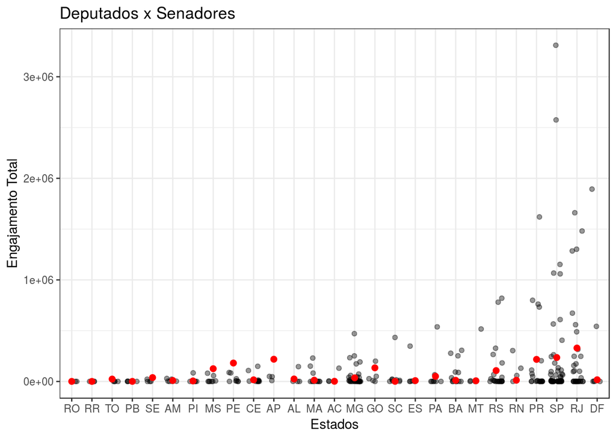

```r
#glimpse(engaj_deputados)

ggplot() +
  geom_jitter(data = engaj_deputados,
              mapping = aes(x = reorder(UF, engaj_total), y = engaj_total),
              width = .3,
              alpha = .4) +
  geom_point(data = media_engaj_senador,
             mapping = aes(x = UF, y = media),
             color = "red",
             size = 2) +
  labs(x = "Estados",
       y = "Engajamento Total",
       title = "Deputados x Senadores")
```

### Dos 27 estados em apenas três - Mato Grosso do Sul, Pernambuco e Amapá - existe uma certa diferença e que a média do engajamento dos senadores é maior, em geral, do que a dos deputados.

## (5.1-) Nesses três casos, os senadores são relamente mais ativos que os deputados ou só são mais populares e alguma vez tiveram seu momento ao sol?

```r
senadores_top = validos %>%
  filter(UF == "MS" | UF == "PE" | UF == "AP") %>%
  group_by(casa, UF) %>%
  select(n_proprio, engaj_total_proprio)
```

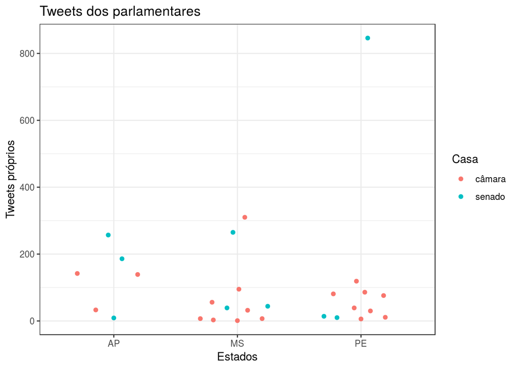

```r
#glimpse(senadores_top)

senadores_top %>%
  ggplot(aes(x = UF, y = n_proprio, color = casa)) +
  geom_quasirandom() +
  labs(x = "Estados",
       y = "Tweets próprios",
       color = "Casa",
       title = "Tweets dos parlamentares")
```

```r
# Descobrindo quem é mais hitado
senado_top_pe = validos %>%
  filter(casa == "senado" & UF == "PE") %>%
  select(nome_eleitoral, n_proprio)

#glimpse(senado_top_pe)
```

## (6-) Quantos parlamentares obtiveram seu maior engajamento com retweets?

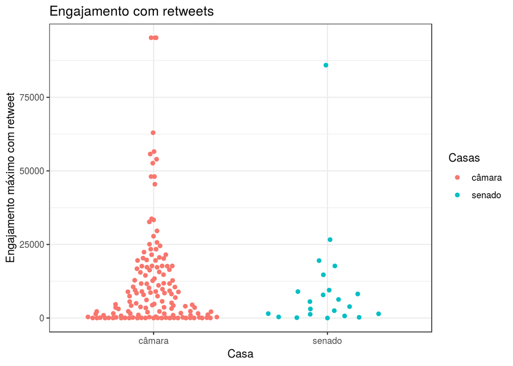

```r
engaj_rt = validos %>%
  filter(engaj_max == engaj_max_retweet)

#glimpse(engaj_rt)

engaj_rt %>%
  ggplot(aes(x = casa, y = engaj_max_retweet, color = casa)) +
  geom_quasirandom() +
  labs(title = "Engajamento com retweets",
       x = "Casa",
       y = "Engajamento máximo com retweet",
       color = "Casas")
```

### Dos 608 parlamentares que obtemos nos dados, tiveram 163 que obtiveram seu maior engajamento a partir de retweet, sendo grande maioria destes com engajamento menor que 25000 reações e a minoria deles acima, incluindo até, pontos isolados com mais de 75000 reações em seus retweets.

## (6.1-) Entre os que obtiveram maior engajamento, em quantos deles esse engajamento com retweet reflete como maior engajamento já obtido por ele?

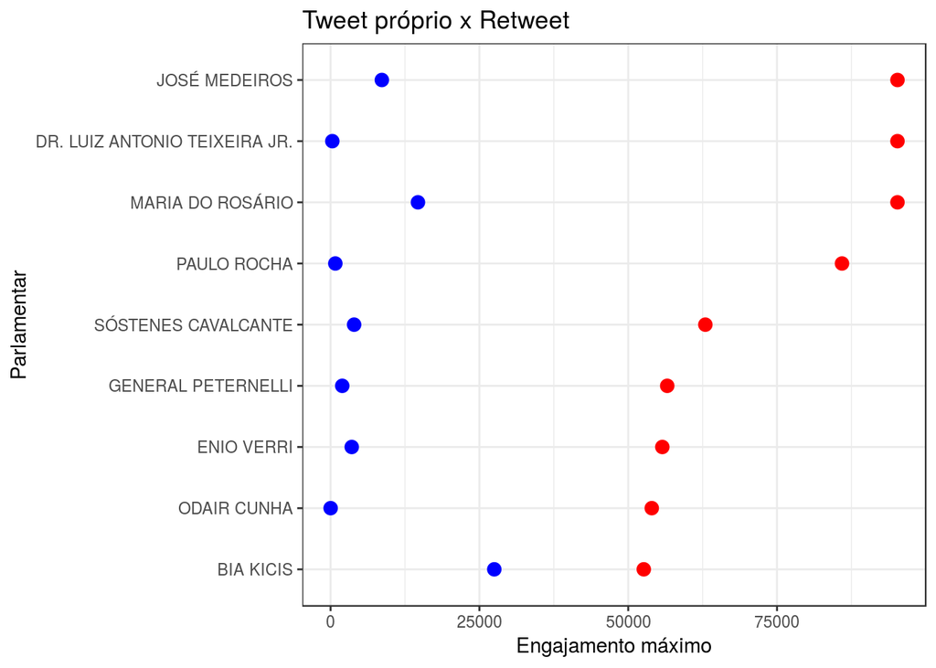

```r
top_engaj = engaj_rt %>%
  filter(engaj_max_retweet > 50000)

#glimpse(top_engaj)

ggplot() +
  geom_point(data = top_engaj,
             mapping = aes(x = reorder(nome_eleitoral, engaj_max), y = engaj_max),
             color = "red",
             size = 3) +
  geom_point(data = top_engaj,
             mapping = aes(x = nome_eleitoral, y = engaj_max_proprio),
             color = "blue",
             size = 3) +
  coord_flip() +
  labs(y = "Engajamento máximo",
       x = "Parlamentar",
       title = "Tweet próprio x Retweet")
```

### Com os pontos vermelhos simbolizando os retweets e os azuis os tweets próprios, entre os nove mais famosos do retweet - que alcançam mais de 50000 reações cada um em seu retweet mais repercutido - nenhum deles conseguiu atingir tanto engajamento com seus tweets próprios e apenas uma parlamentar atingiu metade desse engajamento com tweet próprio.